# A2_C_CheungManYui_3036165325

Cheung Man Yui

2023-11-13

# Q1

Load the data and check for missing values.

```r
awards<-read.csv('awards.csv')
sum(is.na(awards))
```

```
## [1] 0
```

```r
awards$prog <- factor(awards$prog,  levels=c("General","Academic","Vocational"))
head(awards)
```

```
##    id num_awards       prog math
## 1  45          0 Vocational   66
## 2 108          0    General   66
## 3  15          0 Vocational   69
## 4  67          0 Vocational   67
## 5 153          0 Vocational   65
## 6  51          0    General   67
```

Noticed the id is just a unique key of the data from 1-200 and is irrelevant to our analysis, we can just remove it.

```r
awards<-awards[2:4]
```

### Q1.1

```r
library(dplyr)
by_prog <- awards %>% group_by(prog)
by_prog %>% summarise(
  awardsmean=mean(num_awards),
  awardsvar=var(num_awards)
)
```

```
## # A tibble: 3 × 3
##   prog       awardsmean awardsvar
##   <fct>           <dbl>     <dbl>
## 1 General          0.2      0.164
## 2 Academic         1        1.63
## 3 Vocational       0.24     0.268
```

### Q1.2

Since the mean is roughly equal to variance, we can fit Poisson regression to the data.

```r
model1<-glm(num_awards  ~   math    +   prog, data=awards, family=poisson)#fit poisson regression with math and prog
summary(model1)
```

```
##
## Call:
## glm(formula = num_awards ~ math + prog, family = poisson, data = awards)
##
## Coefficients:
##                Estimate Std. Error z value Pr(>|z|)
## (Intercept)    -7.00093    0.89706  -7.804 5.98e-15 ***
## math            0.07015    0.01060   6.619 3.63e-11 ***
## progAcademic    1.08386    0.35825   3.025  0.00248 **
## progVocational  0.36981    0.44107   0.838  0.40179
## ---
## Signif. codes:  0 '***' 0.001 '**' 0.01 '*' 0.05 '.' 0.1 ' ' 1
##
## (Dispersion parameter for poisson family taken to be 1)
##
##     Null deviance: 287.67  on 199  degrees of freedom
## Residual deviance: 189.45  on 196  degrees of freedom
## AIC: 373.5
##
## Number of Fisher Scoring iterations: 6
```

```r
model2<-glm(num_awards  ~   math, data=awards, family=poisson)#fit poisson regression with math only
summary(model2)
```

```
##
## Call:
## glm(formula = num_awards ~ math, family = poisson, data = awards)
##
## Coefficients:
##              Estimate Std. Error z value Pr(>|z|)
## (Intercept) -7.487672   0.831277  -9.007   <2e-16 ***
## math         0.086166   0.009679   8.902   <2e-16 ***
## ---
## Signif. codes:  0 '***' 0.001 '**' 0.01 '*' 0.05 '.' 0.1 ' ' 1
##
## (Dispersion parameter for poisson family taken to be 1)
##
##     Null deviance: 287.67  on 199  degrees of freedom
## Residual deviance: 204.02  on 198  degrees of freedom
## AIC: 384.08
##
## Number of Fisher Scoring iterations: 6
```

```r
anova(model2,model1,test="Chisq")
```

```
## Analysis of Deviance Table
##
## Model 1: num_awards ~ math
## Model 2: num_awards ~ math + prog
##   Resid. Df Resid. Dev Df Deviance  Pr(>Chi)
## 1       198     204.02
## 2       196     189.45  2   14.572 0.0006852 ***
## ---
## Signif. codes:  0 '***' 0.001 '**' 0.01 '*' 0.05 '.' 0.1 ' ' 1
```

From the summary above, we can tell the two models are significantly different, i.e. the prog variable is significant.

### Q1.3

Next we use the first model to predict the awards we expect for a student in Academic with math score of 90 vs student in General with math score of 90.

```r
predictq1<-data.frame(prog=c('Academic','General'),math=c(90,90))#create the prediction dataframe
q1_3<-predict(model1, newdata=predictq1, type="response")
q1_3
```

```
##         1         2
## 1.4868214 0.5029731
```

```r
q1_3[1]-q1_3[2]#compute the difference
```

```
##         1
## 0.9838483
```

Therefore we can say we expect a 0.98 award count difference.  
We can also verify the above using the coefficients from the model. The ratio of award count:

```r
q1_3[1]/q1_3[2]
```

```
##        1
## 2.956065
```

Computation using the coefficients of model:

```r
exp(model1$coefficients[3])
```

```
## progAcademic
##     2.956065
```

# Q2 Lung Cancer Data

```r
lung<-read.table('lungcancer.txt', header = FALSE, sep = " ", dec = ".")#load data
dim(lung)
```

```
## [1] 12625    56
```

```r
sum(is.na(lung)) #check for missing values
```

```
## [1] 0
```

```r
lung_t<-t(lung) #transpose the dataframe
lung_t_scale<-scale(lung_t,center=TRUE, scale=TRUE) #scale data
lung_t_scale<-as.data.frame(lung_t_scale)
head(apply(lung_t_scale,2,mean)) #check the scaled mean
```

```
##            V1            V2            V3            V4            V5
## -1.200367e-19 -1.561251e-17 -5.482239e-18 -2.084766e-17 -2.458816e-18
##            V6
## -1.776349e-17
```

```r
head(apply(lung_t_scale,2,sd)) #check the scaled sd
```

```
## V1 V2 V3 V4 V5 V6
##  1  1  1  1  1  1
```

### Q2.1

```r
pc_1<-prcomp(lung_t_scale, scale=TRUE)#Perform PCA
summary(pc_1)
```

```
## Importance of components:
##                            PC1     PC2      PC3     PC4      PC5      PC6
## Standard deviation     50.8052 38.0526 32.07527 26.6844 24.96534 20.89695
## Proportion of Variance  0.2044  0.1147  0.08149  0.0564  0.04937  0.03459
## Cumulative Proportion   0.2044  0.3191  0.40063  0.4570  0.50640  0.54099
##                             PC7      PC8      PC9     PC10     PC11     PC12
## Standard deviation     19.01180 17.44608 17.02844 16.81463 15.90180 14.90014
## Proportion of Variance  0.02863  0.02411  0.02297  0.02239  0.02003  0.01759
## Cumulative Proportion   0.56962  0.59373  0.61670  0.63909  0.65912  0.67671
##                            PC13     PC14     PC15     PC16     PC17     PC18
## Standard deviation     14.33671 13.68204 13.47583 12.73508 12.47303 12.31128
## Proportion of Variance  0.01628  0.01483  0.01438  0.01285  0.01232  0.01201
## Cumulative Proportion   0.69299  0.70781  0.72220  0.73504  0.74737  0.75937
##                            PC19    PC20     PC21     PC22     PC23     PC24
## Standard deviation     11.75366 11.5671 11.22493 10.84332 10.73431 10.56154
## Proportion of Variance  0.01094  0.0106  0.00998  0.00931  0.00913  0.00884
## Cumulative Proportion   0.77031  0.7809  0.79089  0.80020  0.80933  0.81817
##                            PC25     PC26     PC27     PC28    PC29    PC30
## Standard deviation     10.40424 10.25829 10.15815 10.00291 9.83224 9.72541
## Proportion of Variance  0.00857  0.00834  0.00817  0.00793 0.00766 0.00749
## Cumulative Proportion   0.82674  0.83508  0.84325  0.85118 0.85883 0.86632
##                           PC31    PC32    PC33    PC34    PC35    PC36    PC37
## Standard deviation     9.43479 9.36562 9.20831 9.09100 9.02921 9.01001 8.84051
## Proportion of Variance 0.00705 0.00695 0.00672 0.00655 0.00646 0.00643 0.00619
## Cumulative Proportion  0.87337 0.88032 0.88704 0.89359 0.90004 0.90647 0.91266
##                           PC38    PC39    PC40    PC41    PC42    PC43    PC44
## Standard deviation     8.67532 8.59152 8.54591 8.43000 8.37379 8.28347 8.21472
## Proportion of Variance 0.00596 0.00585 0.00578 0.00563 0.00555 0.00543 0.00535
## Cumulative Proportion  0.91862 0.92447 0.93026 0.93588 0.94144 0.94687 0.95222
##                          PC45    PC46    PC47    PC48    PC49    PC50    PC51
## Standard deviation     8.0217 7.90761 7.79718 7.73543 7.55494 7.46896 7.39256
## Proportion of Variance 0.0051 0.00495 0.00482 0.00474 0.00452 0.00442 0.00433
## Cumulative Proportion  0.9573 0.96227 0.96708 0.97182 0.97634 0.98076 0.98509
##                           PC52    PC53    PC54    PC55      PC56
## Standard deviation     7.24408 7.08031 6.69711 6.38381 4.845e-14
## Proportion of Variance 0.00416 0.00397 0.00355 0.00323 0.000e+00
## Cumulative Proportion  0.98925 0.99322 0.99677 1.00000 1.000e+00
```

```r
library(ggfortify)
```

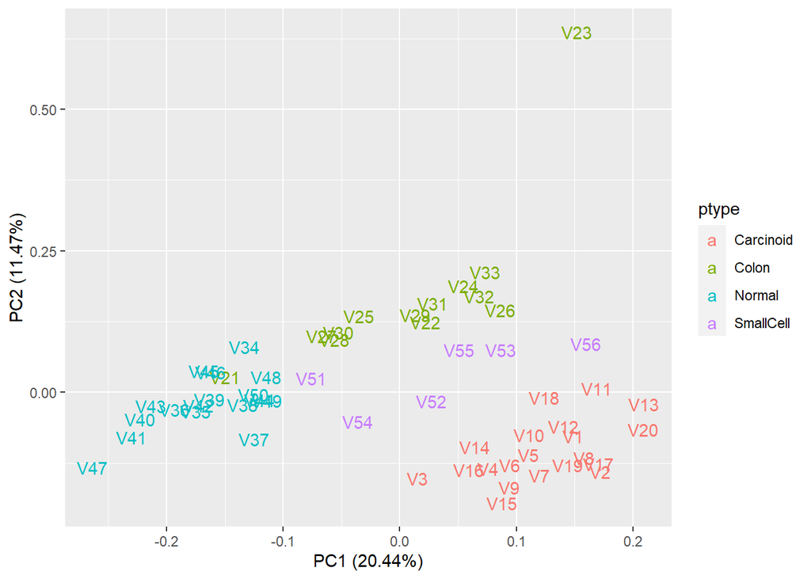

```r
library(ggplot2)

ptype<-rep(c("Carcinoid","Colon","Normal","SmallCell"),times=c(20,13,17,6))
lung_t_scale['ptype']=ptype

autoplot(pc_1, data = lung_t_scale, colour = 'ptype', shape=FALSE)
```

Noted there is a significant outlier(Patient 23) in type Colon, we can consider to remove it from the data and perform pca again.

Extract V23’s data and compare to some of the genes distribution.

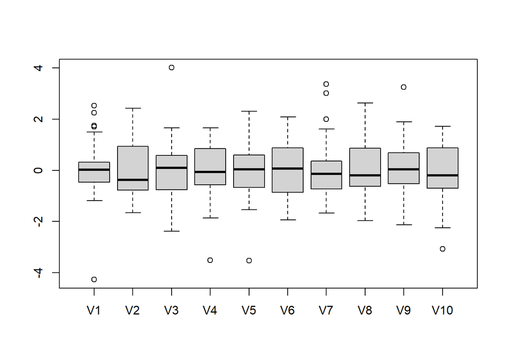

```r
boxplot(lung_t_scale[,1:10])
```

```r
lung_t_scale[lung_t_scale$V1< (-2),1:10]
```

```
##            V1        V2        V3        V4        V5         V6       V7
## V23 -4.264112 -1.650833 -2.374285 -3.513014 -3.523132 0.04350406 1.622137
##            V8         V9       V10
## V23 -1.312758 -0.9300167 -3.068336
```

It can be concluded Patient23 does contribute some extreme values.

```r
lung_t_scale2<-lung_t_scale[-c(23),] #remove patient 23
```

```r
pc_2<-prcomp(lung_t_scale2[,-12626], scale=TRUE)#PCA
summary(pc_2)
```

```
## Importance of components:
##                            PC1     PC2      PC3      PC4      PC5      PC6
## Standard deviation     52.4753 36.7182 27.88480 26.06401 22.42749 20.12299
## Proportion of Variance  0.2181  0.1068  0.06159  0.05381  0.03984  0.03207
## Cumulative Proportion   0.2181  0.3249  0.38649  0.44030  0.48014  0.51221
##                             PC7      PC8      PC9     PC10     PC11     PC12
## Standard deviation     19.71447 18.21333 17.66801 16.83474 15.80742 15.07840
## Proportion of Variance  0.03078  0.02628  0.02473  0.02245  0.01979  0.01801
## Cumulative Proportion   0.54300  0.56927  0.59400  0.61645  0.63624  0.65425
##                            PC13    PC14     PC15     PC16     PC17     PC18
## Standard deviation     14.36515 14.2137 13.58011 13.21515 13.12813 12.48127
## Proportion of Variance  0.01635  0.0160  0.01461  0.01383  0.01365  0.01234
## Cumulative Proportion   0.67059  0.6866  0.70120  0.71504  0.72869  0.74103
##                            PC19    PC20     PC21     PC22     PC23     PC24
## Standard deviation     12.24277 11.8364 11.64913 11.32566 11.14800 10.97020
## Proportion of Variance  0.01187  0.0111  0.01075  0.01016  0.00984  0.00953
## Cumulative Proportion   0.75290  0.7640  0.77475  0.78491  0.79475  0.80428
##                           PC25     PC26     PC27    PC28     PC29     PC30
## Standard deviation     10.8362 10.73552 10.57006 10.4219 10.29102 10.14782
## Proportion of Variance  0.0093  0.00913  0.00885  0.0086  0.00839  0.00816
## Cumulative Proportion   0.8136  0.82271  0.83156  0.8402  0.84855  0.85671
##                           PC31    PC32    PC33    PC34    PC35    PC36    PC37
## Standard deviation     9.95289 9.74672 9.65557 9.60595 9.53929 9.34771 9.23670
## Proportion of Variance 0.00785 0.00752 0.00738 0.00731 0.00721 0.00692 0.00676
## Cumulative Proportion  0.86456 0.87208 0.87946 0.88677 0.89398 0.90090 0.90766
##                           PC38    PC39    PC40    PC41    PC42    PC43    PC44
## Standard deviation     9.10760 9.05061 8.96241 8.88134 8.84274 8.72712 8.62657
## Proportion of Variance 0.00657 0.00649 0.00636 0.00625 0.00619 0.00603 0.00589
## Cumulative Proportion  0.91423 0.92072 0.92708 0.93333 0.93952 0.94555 0.95145
##                           PC45    PC46    PC47    PC48    PC49    PC50   PC51
## Standard deviation     8.46080 8.31939 8.22816 8.06926 7.95398 7.90153 7.7037
## Proportion of Variance 0.00567 0.00548 0.00536 0.00516 0.00501 0.00495 0.0047
## Cumulative Proportion  0.95712 0.96260 0.96796 0.97312 0.97813 0.98308 0.9878
##                           PC52    PC53    PC54      PC55
## Standard deviation     7.50830 7.16943 6.82036 5.017e-14
## Proportion of Variance 0.00447 0.00407 0.00368 0.000e+00
## Cumulative Proportion  0.99224 0.99632 1.00000 1.000e+00
```

To show each PCs are not correlated to each other:

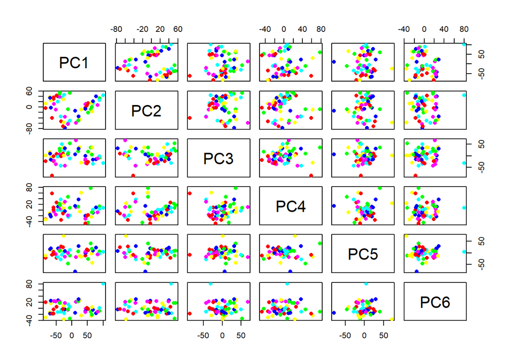

```r
pairs(pc_2$x[1:55,1:6], col=rainbow(6), pch=16)
```

Scree Plot of the model

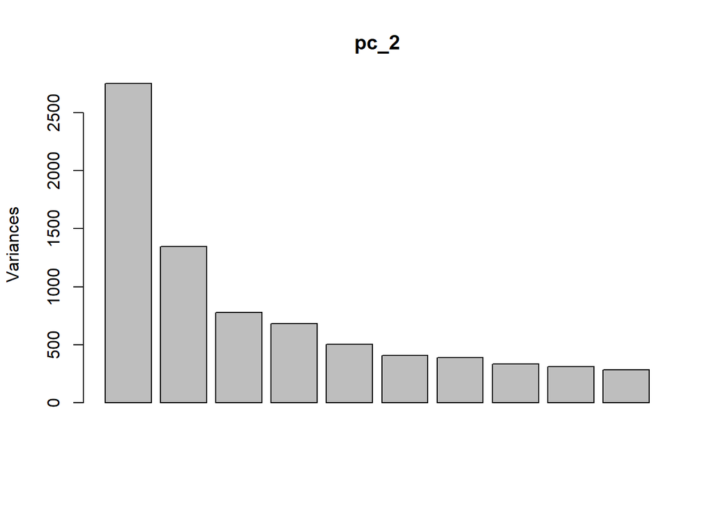

```r
screeplot(pc_2)
```

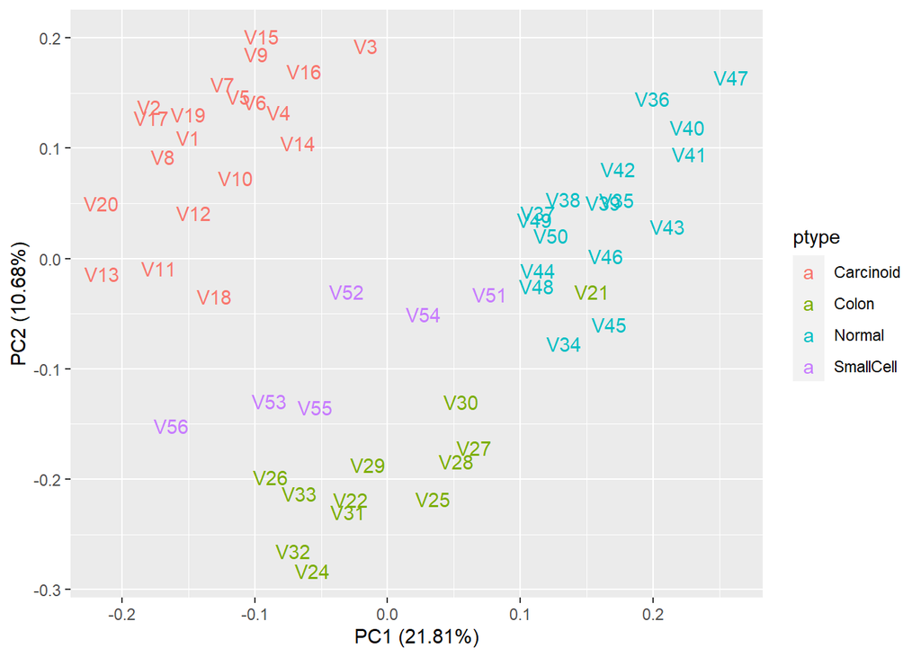

```r
autoplot(pc_2, data = lung_t_scale2, colour = 'ptype', shape=FALSE)
```

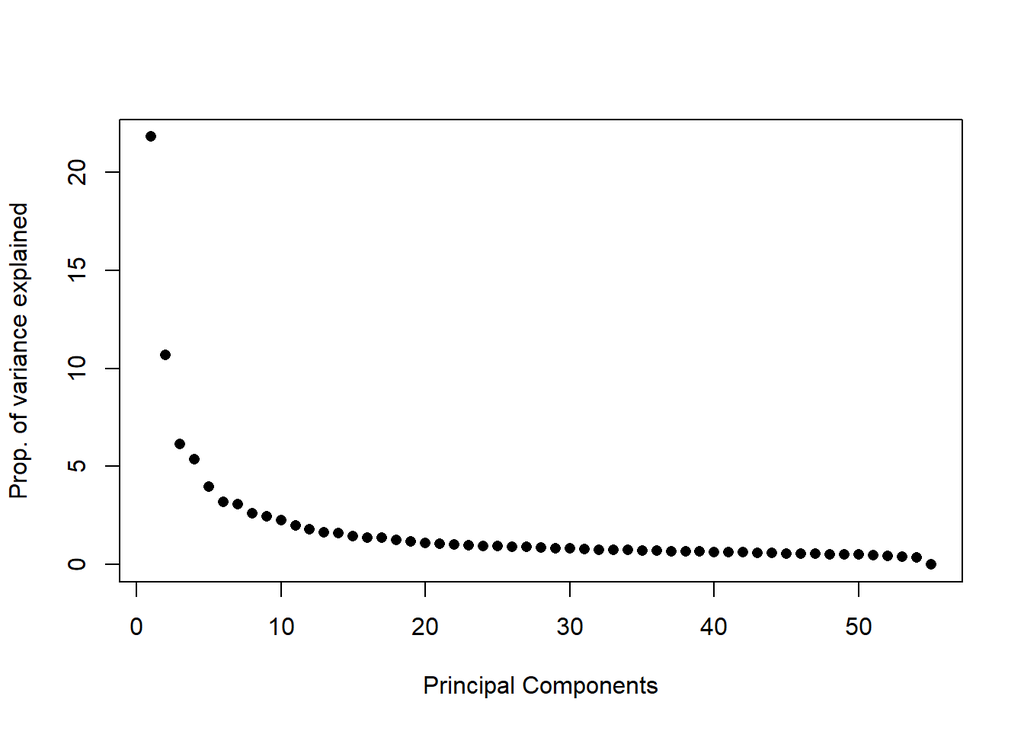

```r
pve <- 100* (pc_2$sdev)**2/sum ((pc_2$sdev)**2)
plot(pve, pch=16,
xlab="Principal Components",
ylab="Prop. of variance explained")
```

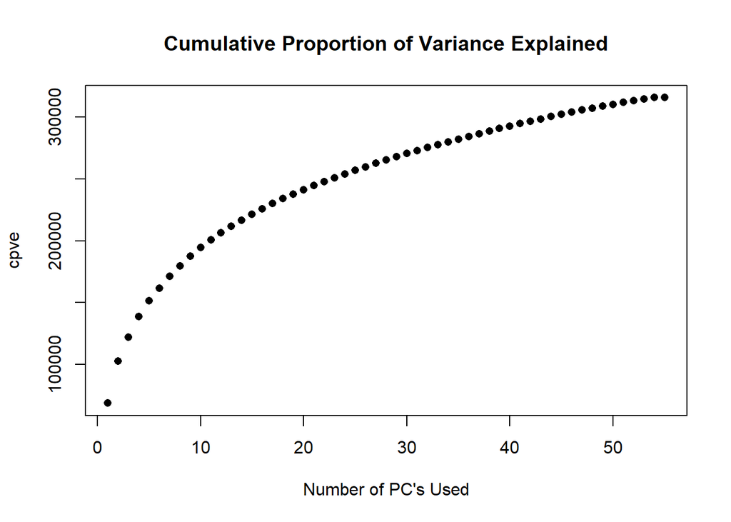

```r
cpve <- 100*cumsum((pc_2$sdev)**2)/4 # cumulative proportions of the variance explained by
# the number of pc's used

plot(seq(1:55), cpve, pch=16,
main="Cumulative Proportion of Variance Explained",
xlab="Number of PC's Used")
```

We can conclude from the summary and the plots that it is not sufficient to only use 3 PCs to explain the data, since the top 3 PCs can only account for around 40% of the total variances.

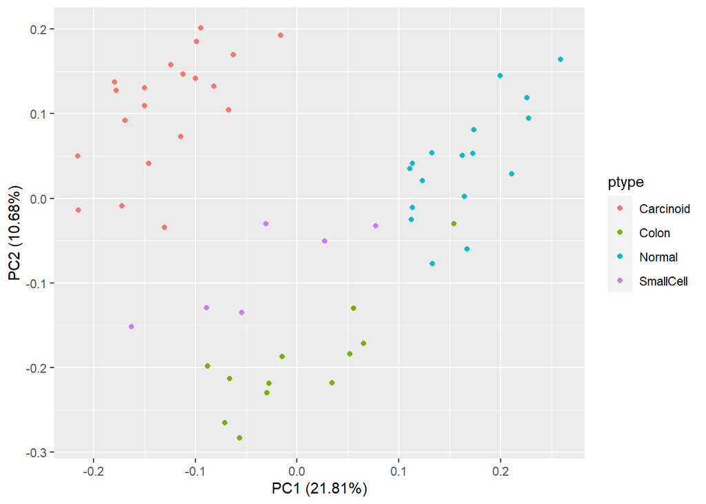

```r
autoplot(pc_2, data = lung_t_scale2, colour = 'ptype') #Show pairwise scatter plot again (PC1 v PC2)
```

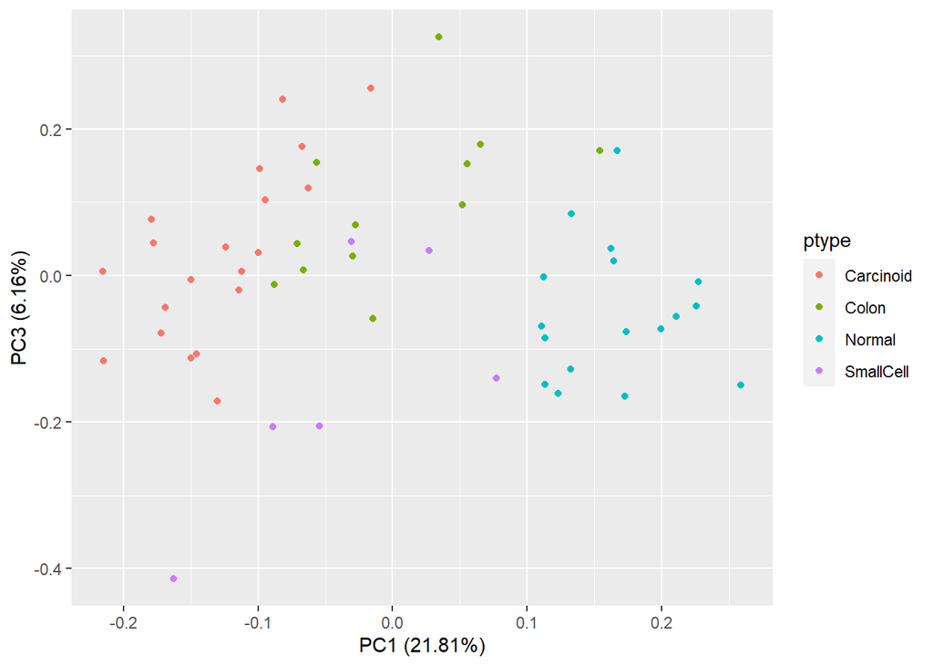

```r
autoplot(pc_2, data = lung_t_scale2, colour = 'ptype', x=1, y=3) #Show pairwise scatter plot of PC1 v PC3
```

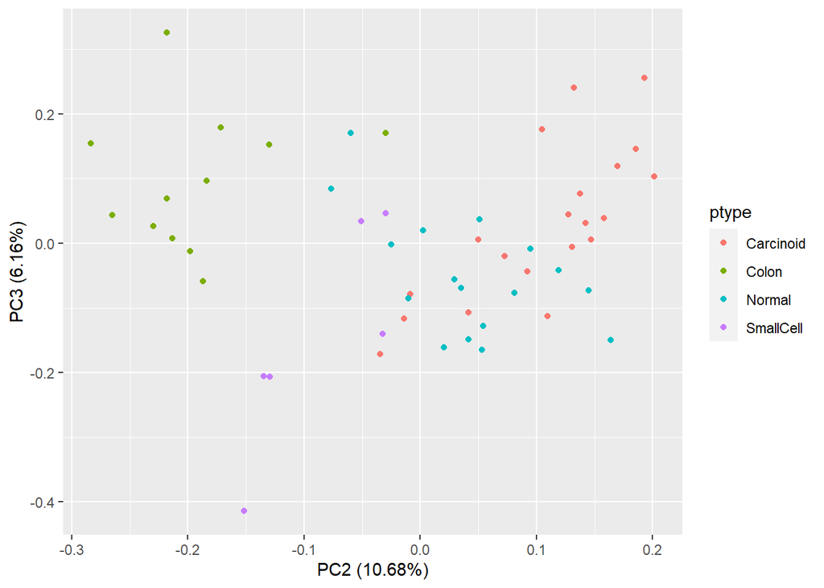

```r
autoplot(pc_2, data = lung_t_scale2, colour = 'ptype', x=2, y=3) #Show pairwise scatter plot of PC2 v PC3
```

From the above plots, we can observe the patient type can only can slightly grouped in terms of PC1 and PC2.  
In general, Normal type patients would have a higher PC1 and higher PC2 components.  
Colon patients would have a low PC2 and medium PC1 components.  
Small Cell patients would have a medium PC1 and PC2 components.  
Carcinoid patients would have a low PC1 and high PC2 component.

However, as we have identified above, the top 3 PC can only explains around 40% of the variances in the data, therefore this might not be a good model to classify patient types.

### Q2.2

Multinomial Logistic Regression

```r
library(nnet)
set.seed(1)
train_2_2<-data.frame(pc_2$x[,c(1:3)],lung_t_scale2[,12626])#extract the first 3 PCs and the patient type
colnames(train_2_2)[4]<-"ptype"
logmodel<-multinom(ptype~.,train_2_2, maxit=200)#perform multinomial logistic regression
summary(logmodel)
```

```
## Call:
## multinom(formula = ptype ~ ., data = train_2_2, maxit = 200)
##
## Coefficients:
##           (Intercept)       PC1        PC2       PC3
## Colon       -60.28383  9.104878 -16.430929 12.935772
## Normal     -104.98630 18.580414 -13.006697 -1.407088
## SmallCell   179.20101  9.452417  -7.723373 -3.006614
##
## Std. Errors:
##           (Intercept)       PC1      PC2      PC3
## Colon        328.6774 11.652720 6.146424 13.40325
## Normal       535.9197  9.378151 8.750470 11.32081
## SmallCell    207.2472 14.015506 6.586254 16.68566
##
## Residual Deviance: 0.0006044409
## AIC: 24.0006
```

LDA

```r
library(DiscriMiner)
ldamodel<-linDA(train_2_2[,1:3],train_2_2[,4])
ldamodel$functions
```

```
##            Carcinoid       Colon     Normal   SmallCell
## constant -14.5596327 -9.87534588 -9.3977403 -3.89101340
## PC1       -0.3309840  0.14807608  0.2644855  0.05775209
## PC2        0.3401735 -0.30402911 -0.1502391 -0.10017597
## PC3        0.0982544  0.03079339 -0.1163329 -0.05949161
```

```r
ldamodel$confusion
```

```
##            predicted
## original    Carcinoid Colon Normal SmallCell
##   Carcinoid        19     0      0         1
##   Colon             0    11      1         0
##   Normal            0     0     17         0
##   SmallCell         0     0      1         5
```

SVM

```r
library(e1071)
train_2_2[,4]<-as.factor(train_2_2[,4])
svmmodel <- svm(ptype ~ ., data = train_2_2, kernel = "linear",cost = 10, scale = FALSE)
summary(svmmodel)
```

```
##
## Call:
## svm(formula = ptype ~ ., data = train_2_2, kernel = "linear", cost = 10,
##     scale = FALSE)
##
##
## Parameters:
##    SVM-Type:  C-classification
##  SVM-Kernel:  linear
##        cost:  10
##
## Number of Support Vectors:  16
##
##  ( 3 4 5 4 )
##
##
## Number of Classes:  4
##
## Levels:
##  Carcinoid Colon Normal SmallCell
```

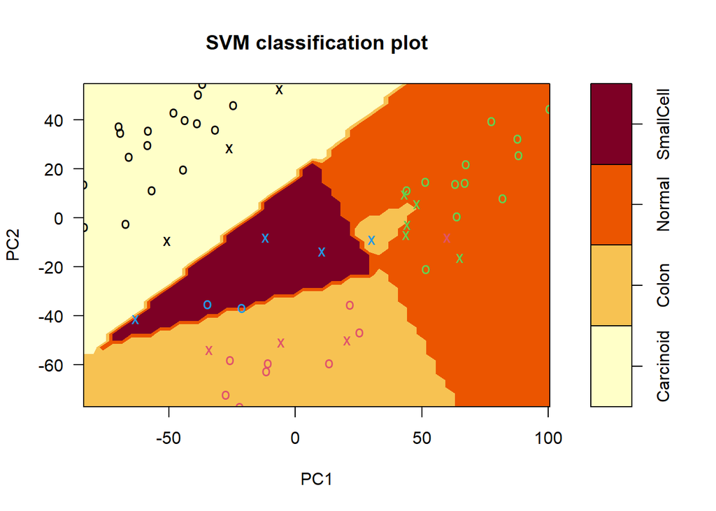

```r
plot(svmmodel, train_2_2, PC2~PC1)
```

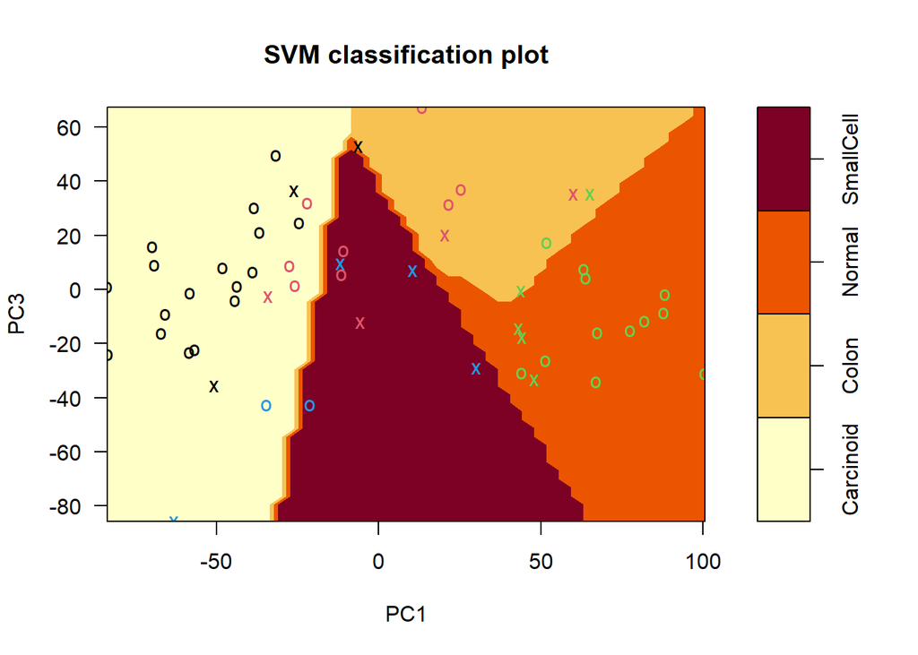

```r
plot(svmmodel, train_2_2, PC3~PC1)
```

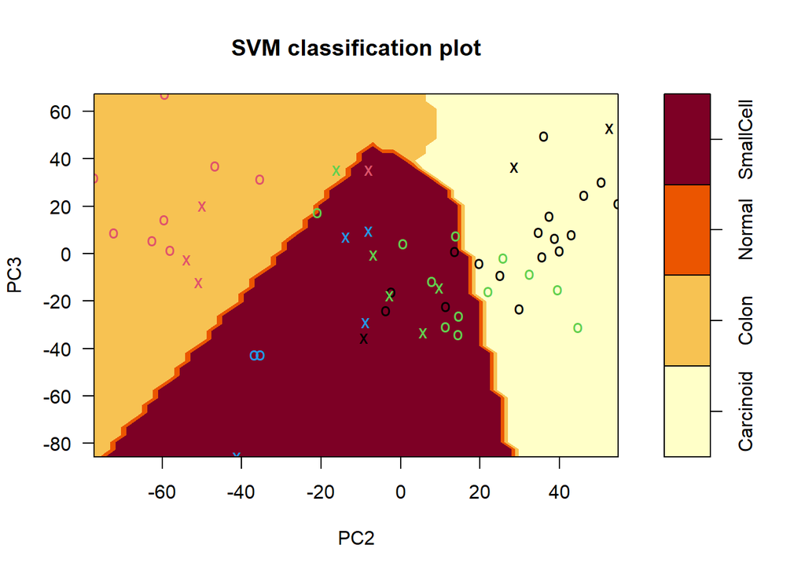

```r
plot(svmmodel, train_2_2, PC3~PC2)
```

### Q2.3

```r
km.out<-kmeans(train_2_2[,1:3],4,nstart=20)
km.out$cluster
```

```
##  V1  V2  V3  V4  V5  V6  V7  V8  V9 V10 V11 V12 V13 V14 V15 V16 V17 V18 V19 V20
##   3   3   3   3   3   3   3   3   3   3   4   4   4   3   3   3   3   4   3   3
## V21 V22 V24 V25 V26 V27 V28 V29 V30 V31 V32 V33 V34 V35 V36 V37 V38 V39 V40 V41
##   2   1   1   1   1   1   1   1   1   1   1   1   2   2   2   2   2   2   2   2
## V42 V43 V44 V45 V46 V47 V48 V49 V50 V51 V52 V53 V54 V55 V56
##   2   2   2   2   2   2   2   2   2   2   1   4   1   4   4
```

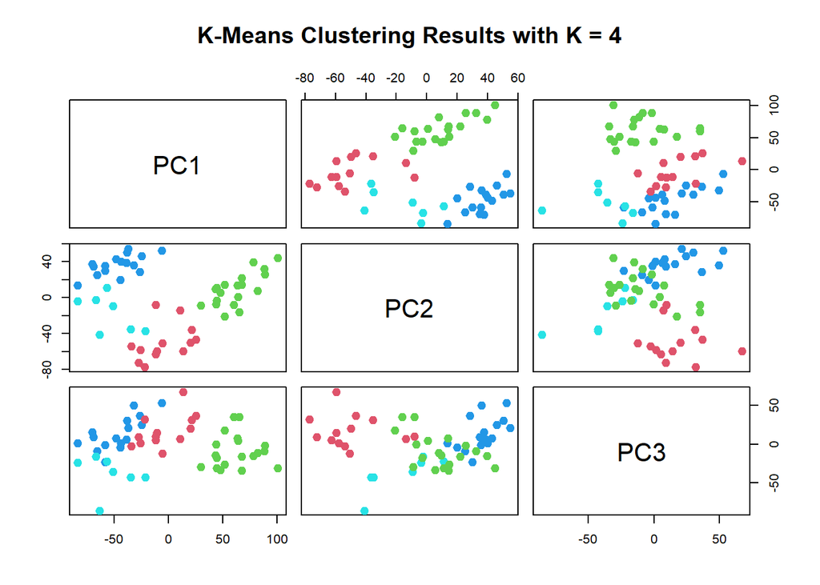

```r
plot(train_2_2[,1:3], col = (km.out$cluster + 1), main = "K-Means Clustering Results with K = 4",
 pch = 20, cex = 2)
```

```r
library(rgl)
plot3d(train_2_2[,1:3])
```

[output not shown]

```r
 open3d()
```

```
## wgl
##   2
```

```r
  x <- sort(rnorm(1000))
  y <- rnorm(1000)
  z <- rnorm(1000) + atan2(x, y)
  plot3d(x, y, z, col = rainbow(1000))
```

[output not shown]